### **Objetivo**

O objetivo desta análise é utilizar um modelo de classificação, para a prever de ocorrência de câncer de mama.

### **Os dados**

Os dados utilizados aqui estão disponíveis no repositório da [UCI Machine Learning Repository](https://archive-beta.ics.uci.edu/ml/datasets/breast+cancer+wisconsin+diagnostic) e foram obtidos dos Hospitais da Universidade de Wisconsin, Madison, do Dr. William H. Wolberg.

[figure not shown]

O conjunto de dados possui 569 observações de biópsias de câncer, com cada observação possuindo 32 variáveis. As duas primeiras se referem ao número de ID e a segunda, ao diagnóstico sendo M = maligno e B = benigno. As demais 30 variáveis, são relativas a dez características de valor real são computadas para cada núcleo de célula:

1. raio (média das distâncias do centro aos pontos do perímetro)
2. textura (desvio padrão dos valores de escala de cinza)
3. perímetro
4. área
5. suavidade (variação local nos comprimentos dos raios)
6. compacidade (perímetro^2 / área - 1,0)
7. concavidade (gravidade das porções côncavas do contorno)
8. pontos côncavos (número de porções côncavas do contorno)
9. simetria
10. dimensão fractal (“aproximação do litoral” - 1)

A média, o erro padrão e o “pior” ou maior (média dos três maiores valores) desses recursos foram calculados para cada imagem, resultando assim nas 30 características.

### **Pré-processamento**

Vamos agora inicar o processo de análise. Primeiramente vamos definir o diretório de trabalho e carregar os dados:

```r
 setwd("~/Machine-Learning/R")
```

```r
dados <- read.csv("dataset.csv")
dados
```

| id | diagnosis | radius_mean | texture_mean | perimeter_mean | area_mean | smoothness_mean | compactness_mean | concavity_mean | points_mean | symmetry_mean | dimension_mean | radius_se | texture_se | perimeter_se | area_se | smoothness_se | compactness_se | concavity_se | points_se | symmetry_se | dimension_se | radius_worst | texture_worst | perimeter_worst | area_worst | smoothness_worst | compactness_worst | concavity_worst | points_worst | … |
| --- | --- | --- | --- | --- | --- | --- | --- | --- | --- | --- | --- | --- | --- | --- | --- | --- | --- | --- | --- | --- | --- | --- | --- | --- | --- | --- | --- | --- | --- | --- |
| 87139402 | B | 12.320 | 12.39 | 78.85 | 464.1 | 0.10280 | 0.06981 | 0.0398700 | 0.037000 | 0.1959 | 0.05955 | 0.2360 | 0.6656 | 1.6700 | 17.430 | 0.008045 | 0.011800 | 0.0168300 | 0.012410 | 0.019240 | 0.0022480 | 13.500 | 15.64 | 86.97 | 549.1 | 0.13850 | 0.12660 | 0.124200 | 0.093910 | … |
| 8910251 | B | 10.600 | 18.95 | 69.28 | 346.4 | 0.09688 | 0.11470 | 0.0638700 | 0.026420 | 0.1922 | 0.06491 | 0.4505 | 1.1970 | 3.4300 | 27.100 | 0.007470 | 0.035810 | 0.0335400 | 0.013650 | 0.035040 | 0.0033180 | 11.880 | 22.94 | 78.28 | 424.8 | 0.12130 | 0.25150 | 0.191600 | 0.079260 | … |
| 905520 | B | 11.040 | 16.83 | 70.92 | 373.2 | 0.10770 | 0.07804 | 0.0304600 | 0.024800 | 0.1714 | 0.06340 | 0.1967 | 1.3870 | 1.3420 | 13.540 | 0.005158 | 0.009355 | 0.0105600 | 0.007483 | 0.017180 | 0.0021980 | 12.410 | 26.44 | 79.93 | 471.4 | 0.13690 | 0.14820 | 0.106700 | 0.074310 | … |
| 868871 | B | 11.280 | 13.39 | 73.00 | 384.8 | 0.11640 | 0.11360 | 0.0463500 | 0.047960 | 0.1771 | 0.06072 | 0.3384 | 1.3430 | 1.8510 | 26.330 | 0.011270 | 0.034980 | 0.0218700 | 0.019650 | 0.015800 | 0.0034420 | 11.920 | 15.77 | 76.53 | 434.0 | 0.13670 | 0.18220 | 0.086690 | 0.086110 | … |
| 9012568 | B | 15.190 | 13.21 | 97.65 | 711.8 | 0.07963 | 0.06934 | 0.0339300 | 0.026570 | 0.1721 | 0.05544 | 0.1783 | 0.4125 | 1.3380 | 17.720 | 0.005012 | 0.014850 | 0.0155100 | 0.009155 | 0.016470 | 0.0017670 | 16.200 | 15.73 | 104.50 | 819.1 | 0.11260 | 0.17370 | 0.136200 | 0.081780 | … |
| 906539 | B | 11.570 | 19.04 | 74.20 | 409.7 | 0.08546 | 0.07722 | 0.0548500 | 0.014280 | 0.2031 | 0.06267 | 0.2864 | 1.4400 | 2.2060 | 20.300 | 0.007278 | 0.020470 | 0.0444700 | 0.008799 | 0.018680 | 0.0033390 | 13.070 | 26.98 | 86.43 | 520.5 | 0.12490 | 0.19370 | 0.256000 | 0.066640 | … |
| 925291 | B | 11.510 | 23.93 | 74.52 | 403.5 | 0.09261 | 0.10210 | 0.1112000 | 0.041050 | 0.1388 | 0.06570 | 0.2388 | 2.9040 | 1.9360 | 16.970 | 0.008200 | 0.029820 | 0.0573800 | 0.012670 | 0.014880 | 0.0047380 | 12.480 | 37.16 | 82.28 | 474.2 | 0.12980 | 0.25170 | 0.363000 | 0.096530 | … |
| 87880 | M | 13.810 | 23.75 | 91.56 | 597.8 | 0.13230 | 0.17680 | 0.1558000 | 0.091760 | 0.2251 | 0.07421 | 0.5648 | 1.9300 | 3.9090 | 52.720 | 0.008824 | 0.031080 | 0.0311200 | 0.012910 | 0.019980 | 0.0045060 | 19.200 | 41.85 | 128.50 | 1153.0 | 0.22260 | 0.52090 | 0.464600 | 0.201300 | … |
| 862989 | B | 10.490 | 19.29 | 67.41 | 336.1 | 0.09989 | 0.08578 | 0.0299500 | 0.012010 | 0.2217 | 0.06481 | 0.3550 | 1.5340 | 2.3020 | 23.130 | 0.007595 | 0.022190 | 0.0288000 | 0.008614 | 0.027100 | 0.0034510 | 11.540 | 23.31 | 74.22 | 402.8 | 0.12190 | 0.14860 | 0.079870 | 0.032030 | … |
| 89827 | B | 11.060 | 14.96 | 71.49 | 373.9 | 0.10330 | 0.09097 | 0.0539700 | 0.033410 | 0.1776 | 0.06907 | 0.1601 | 0.8225 | 1.3550 | 10.800 | 0.007416 | 0.018770 | 0.0275800 | 0.010100 | 0.023480 | 0.0029170 | 11.920 | 19.90 | 79.76 | 440.0 | 0.14180 | 0.22100 | 0.229900 | 0.107500 | … |

[output cut: 559 more lines]

As informações da coluna `id` não são características que devem ser utilizadas no processo de previsão, deste modo, ela será excluída da análise. Além disso, na coluna `diagnosis`, os valores B e M foram interpretados como caracteres, mas na realidade são fatores que representam dois tipos de resultados. Vamos então aplicar essas alterações:

```r
# remover a coluna id

dados <- dados[,-1]

# transformar em fator a variável diagnosis
dados$diagnosis <- as.factor(dados$diagnosis)

# visualizar os primeiros dados
head(dados)
```

| diagnosis | radius_mean | texture_mean | perimeter_mean | area_mean | smoothness_mean | compactness_mean | concavity_mean | points_mean | symmetry_mean | dimension_mean | radius_se | texture_se | perimeter_se | area_se | smoothness_se | compactness_se | concavity_se | points_se | symmetry_se | dimension_se | radius_worst | texture_worst | perimeter_worst | area_worst | smoothness_worst | compactness_worst | concavity_worst | points_worst | symmetry_worst | … |
| --- | --- | --- | --- | --- | --- | --- | --- | --- | --- | --- | --- | --- | --- | --- | --- | --- | --- | --- | --- | --- | --- | --- | --- | --- | --- | --- | --- | --- | --- | --- |
| B | 12.32 | 12.39 | 78.85 | 464.1 | 0.10280 | 0.06981 | 0.03987 | 0.03700 | 0.1959 | 0.05955 | 0.2360 | 0.6656 | 1.670 | 17.43 | 0.008045 | 0.011800 | 0.01683 | 0.012410 | 0.01924 | 0.002248 | 13.50 | 15.64 | 86.97 | 549.1 | 0.1385 | 0.1266 | 0.12420 | 0.09391 | 0.2827 | … |
| B | 10.60 | 18.95 | 69.28 | 346.4 | 0.09688 | 0.11470 | 0.06387 | 0.02642 | 0.1922 | 0.06491 | 0.4505 | 1.1970 | 3.430 | 27.10 | 0.007470 | 0.035810 | 0.03354 | 0.013650 | 0.03504 | 0.003318 | 11.88 | 22.94 | 78.28 | 424.8 | 0.1213 | 0.2515 | 0.19160 | 0.07926 | 0.2940 | … |
| B | 11.04 | 16.83 | 70.92 | 373.2 | 0.10770 | 0.07804 | 0.03046 | 0.02480 | 0.1714 | 0.06340 | 0.1967 | 1.3870 | 1.342 | 13.54 | 0.005158 | 0.009355 | 0.01056 | 0.007483 | 0.01718 | 0.002198 | 12.41 | 26.44 | 79.93 | 471.4 | 0.1369 | 0.1482 | 0.10670 | 0.07431 | 0.2998 | … |
| B | 11.28 | 13.39 | 73.00 | 384.8 | 0.11640 | 0.11360 | 0.04635 | 0.04796 | 0.1771 | 0.06072 | 0.3384 | 1.3430 | 1.851 | 26.33 | 0.011270 | 0.034980 | 0.02187 | 0.019650 | 0.01580 | 0.003442 | 11.92 | 15.77 | 76.53 | 434.0 | 0.1367 | 0.1822 | 0.08669 | 0.08611 | 0.2102 | … |
| B | 15.19 | 13.21 | 97.65 | 711.8 | 0.07963 | 0.06934 | 0.03393 | 0.02657 | 0.1721 | 0.05544 | 0.1783 | 0.4125 | 1.338 | 17.72 | 0.005012 | 0.014850 | 0.01551 | 0.009155 | 0.01647 | 0.001767 | 16.20 | 15.73 | 104.50 | 819.1 | 0.1126 | 0.1737 | 0.13620 | 0.08178 | 0.2487 | … |
| B | 11.57 | 19.04 | 74.20 | 409.7 | 0.08546 | 0.07722 | 0.05485 | 0.01428 | 0.2031 | 0.06267 | 0.2864 | 1.4400 | 2.206 | 20.30 | 0.007278 | 0.020470 | 0.04447 | 0.008799 | 0.01868 | 0.003339 | 13.07 | 26.98 | 86.43 | 520.5 | 0.1249 | 0.1937 | 0.25600 | 0.06664 | 0.3035 | … |

Note que agora a coluna `diagnosis` é do tipo fator, o que também pode ser verificado com a função `str()`:

```r
str(dados$diagnosis)
```

```
##  Factor w/ 2 levels "B","M": 1 1 1 1 1 1 1 2 1 1 ...
```

Apesar de não ser necessário, podemos modificar os nomes dos fatores para deixar mais intuitivo:

```r
levels(dados$diagnosis) <- c('benigno', 'maligno')
head(dados)
```

| diagnosis | radius_mean | texture_mean | perimeter_mean | area_mean | smoothness_mean | compactness_mean | concavity_mean | points_mean | symmetry_mean | dimension_mean | radius_se | texture_se | perimeter_se | area_se | smoothness_se | compactness_se | concavity_se | points_se | symmetry_se | dimension_se | radius_worst | texture_worst | perimeter_worst | area_worst | smoothness_worst | compactness_worst | concavity_worst | points_worst | symmetry_worst | … |
| --- | --- | --- | --- | --- | --- | --- | --- | --- | --- | --- | --- | --- | --- | --- | --- | --- | --- | --- | --- | --- | --- | --- | --- | --- | --- | --- | --- | --- | --- | --- |
| benigno | 12.32 | 12.39 | 78.85 | 464.1 | 0.10280 | 0.06981 | 0.03987 | 0.03700 | 0.1959 | 0.05955 | 0.2360 | 0.6656 | 1.670 | 17.43 | 0.008045 | 0.011800 | 0.01683 | 0.012410 | 0.01924 | 0.002248 | 13.50 | 15.64 | 86.97 | 549.1 | 0.1385 | 0.1266 | 0.12420 | 0.09391 | 0.2827 | … |
| benigno | 10.60 | 18.95 | 69.28 | 346.4 | 0.09688 | 0.11470 | 0.06387 | 0.02642 | 0.1922 | 0.06491 | 0.4505 | 1.1970 | 3.430 | 27.10 | 0.007470 | 0.035810 | 0.03354 | 0.013650 | 0.03504 | 0.003318 | 11.88 | 22.94 | 78.28 | 424.8 | 0.1213 | 0.2515 | 0.19160 | 0.07926 | 0.2940 | … |
| benigno | 11.04 | 16.83 | 70.92 | 373.2 | 0.10770 | 0.07804 | 0.03046 | 0.02480 | 0.1714 | 0.06340 | 0.1967 | 1.3870 | 1.342 | 13.54 | 0.005158 | 0.009355 | 0.01056 | 0.007483 | 0.01718 | 0.002198 | 12.41 | 26.44 | 79.93 | 471.4 | 0.1369 | 0.1482 | 0.10670 | 0.07431 | 0.2998 | … |
| benigno | 11.28 | 13.39 | 73.00 | 384.8 | 0.11640 | 0.11360 | 0.04635 | 0.04796 | 0.1771 | 0.06072 | 0.3384 | 1.3430 | 1.851 | 26.33 | 0.011270 | 0.034980 | 0.02187 | 0.019650 | 0.01580 | 0.003442 | 11.92 | 15.77 | 76.53 | 434.0 | 0.1367 | 0.1822 | 0.08669 | 0.08611 | 0.2102 | … |
| benigno | 15.19 | 13.21 | 97.65 | 711.8 | 0.07963 | 0.06934 | 0.03393 | 0.02657 | 0.1721 | 0.05544 | 0.1783 | 0.4125 | 1.338 | 17.72 | 0.005012 | 0.014850 | 0.01551 | 0.009155 | 0.01647 | 0.001767 | 16.20 | 15.73 | 104.50 | 819.1 | 0.1126 | 0.1737 | 0.13620 | 0.08178 | 0.2487 | … |
| benigno | 11.57 | 19.04 | 74.20 | 409.7 | 0.08546 | 0.07722 | 0.05485 | 0.01428 | 0.2031 | 0.06267 | 0.2864 | 1.4400 | 2.206 | 20.30 | 0.007278 | 0.020470 | 0.04447 | 0.008799 | 0.01868 | 0.003339 | 13.07 | 26.98 | 86.43 | 520.5 | 0.1249 | 0.1937 | 0.25600 | 0.06664 | 0.3035 | … |

Vamos agora observar as proporções de resultados benigno e maligno:

```r
library('dplyr')      # para manipulação de dados
library('tidyr')      # para remodelar os dados

prop <- dados %>%
  count(diagnosis) %>%
  mutate(porcentagem = round(prop.table(n)*100,2))

prop
```

| diagnosis | n | porcentagem |
| --- | --- | --- |
| benigno | 357 | 62.74 |
| maligno | 212 | 37.26 |

Olhando para a tabela dos dados podemos notar que, em cada coluna, a escala dos dados não é a mesma, de modo que é necessário aplicar a normalização. O objetivo da normalização é mudar os valores das colunas numéricas para usar uma escala comum, sem distorcer as diferenças nos intervalos de valores nem perder informações. A normalização também é necessária para alguns algoritmos modelem os dados corretamente.

Vamos usar aqui o normalizador **MinMax** de mínimo e máximo, que redimensiona os dados linearmente no intervalo [0,1]. A formula para o normalizador **MinMax** é

$$x_{normalizado} = \frac{x - x_{min}}{x_{max}-x_{min}}$$

em que $x$ é o valor original, $x_{min}$ e $x_{max}$ são respectivamente, o menor e o maior valores de $x$ na coluna.

Vamos então construir uma função para normalizar os dados:

```r
normalize <- function(x) {
  return((x - min(x))/(max(x) - min(x)))
}
```

Alicando a função:

```r
dados_norm <- data.frame(lapply(dados[,2:31],normalize))
dados_norm
```

| radius_mean | texture_mean | perimeter_mean | area_mean | smoothness_mean | compactness_mean | concavity_mean | points_mean | symmetry_mean | dimension_mean | radius_se | texture_se | perimeter_se | area_se | smoothness_se | compactness_se | concavity_se | points_se | symmetry_se | dimension_se | radius_worst | texture_worst | perimeter_worst | area_worst | smoothness_worst | compactness_worst | concavity_worst | points_worst | symmetry_worst | dimension_worst |
| --- | --- | --- | --- | --- | --- | --- | --- | --- | --- | --- | --- | --- | --- | --- | --- | --- | --- | --- | --- | --- | --- | --- | --- | --- | --- | --- | --- | --- | --- |
| 0.25268588 | 0.09063240 | 0.24227766 | 0.13599152 | 0.45292047 | 0.15468376 | 0.093416120 | 0.183896620 | 0.45404040 | 0.201979781 | 0.045084193 | 0.0674946959 | 0.0430193658 | 0.0198506532 | 0.21524969 | 0.071709676 | 0.042500000 | 0.23508240 | 0.15981877 | 0.046750411 | 0.19815012 | 0.09648188 | 0.18208078 | 0.089436689 | 0.44462788 | 0.096351059 | 0.099201278 | 0.32271478 | 0.248767987 | 0.083103765 |
| 0.17128118 | 0.31247886 | 0.17614539 | 0.08606575 | 0.39947639 | 0.29237470 | 0.149648547 | 0.131312127 | 0.43535354 | 0.314869419 | 0.122759370 | 0.1849363508 | 0.1259482637 | 0.0379119832 | 0.19570316 | 0.252035329 | 0.084696970 | 0.25857170 | 0.38214105 | 0.083716817 | 0.14051939 | 0.29104478 | 0.13880173 | 0.058887141 | 0.33104405 | 0.217529664 | 0.153035144 | 0.27237113 | 0.271042775 | 0.136626000 |
| 0.19210564 | 0.24078458 | 0.18747841 | 0.09743372 | 0.49715627 | 0.17992761 | 0.071368322 | 0.123260437 | 0.33030303 | 0.283066554 | 0.030852797 | 0.2269271570 | 0.0275644348 | 0.0125850302 | 0.11710915 | 0.053346652 | 0.026666667 | 0.14175033 | 0.13083244 | 0.045023009 | 0.15937389 | 0.38432836 | 0.14701927 | 0.070340149 | 0.43406194 | 0.117307487 | 0.085223642 | 0.25536082 | 0.282475853 | 0.155909747 |
| 0.20346443 | 0.12445046 | 0.20185198 | 0.10235419 | 0.57569739 | 0.28900067 | 0.108598875 | 0.238369781 | 0.35909091 | 0.226621735 | 0.082165490 | 0.2172029703 | 0.0515478490 | 0.0364738008 | 0.32488017 | 0.245801664 | 0.055227273 | 0.37222959 | 0.11141442 | 0.088000774 | 0.14194237 | 0.09994670 | 0.13008616 | 0.061148250 | 0.43274120 | 0.150294457 | 0.069241214 | 0.29591065 | 0.105854524 | 0.083956448 |
| 0.38851815 | 0.11836321 | 0.37219266 | 0.24106045 | 0.24374831 | 0.15324213 | 0.079498594 | 0.132057654 | 0.33383838 | 0.115417018 | 0.024189752 | 0.0115585219 | 0.0273759600 | 0.0203923063 | 0.11214604 | 0.094616517 | 0.039166667 | 0.17342300 | 0.12084201 | 0.030132803 | 0.29420135 | 0.09888060 | 0.26938593 | 0.155795320 | 0.27359176 | 0.142047715 | 0.108785942 | 0.28103093 | 0.181746501 | 0.082775810 |
| 0.21718964 | 0.31552249 | 0.21014443 | 0.11291622 | 0.29637989 | 0.17741243 | 0.128514527 | 0.070974155 | 0.49040404 | 0.267691660 | 0.063335144 | 0.2386403819 | 0.0682749847 | 0.0252111513 | 0.18917633 | 0.136825187 | 0.112297980 | 0.16667930 | 0.15193899 | 0.084442325 | 0.18285308 | 0.39872068 | 0.17939140 | 0.082407589 | 0.35481741 | 0.161451815 | 0.204472843 | 0.22900344 | 0.289769367 | 0.182342910 |
| 0.21434995 | 0.48089280 | 0.21235575 | 0.11028632 | 0.36092805 | 0.25372677 | 0.260543580 | 0.204025845 | 0.16565657 | 0.331508003 | 0.046098135 | 0.5621905941 | 0.0555529379 | 0.0189914792 | 0.22051875 | 0.207047796 | 0.144898990 | 0.24000758 | 0.09846907 | 0.132775037 | 0.16186411 | 0.67004264 | 0.15872304 | 0.071028313 | 0.38717559 | 0.217723705 | 0.289936102 | 0.33171821 | 0.107825744 | 0.211727666 |
| 0.32320507 | 0.47480555 | 0.33010849 | 0.19270414 | 0.71923806 | 0.48285381 | 0.365042174 | 0.456063618 | 0.60151515 | 0.510741365 | 0.164149919 | 0.3469324611 | 0.1485181171 | 0.0857642352 | 0.24173097 | 0.216510950 | 0.078585859 | 0.24455389 | 0.17023133 | 0.124759891 | 0.40092494 | 0.79504264 | 0.38891379 | 0.237858828 | 1.00000000 | 0.478902892 | 0.371086262 | 0.69175258 | 0.565148827 | 0.351305260 |
| 0.16607506 | 0.32397700 | 0.16322300 | 0.08169671 | 0.42664981 | 0.20366849 | 0.070173383 | 0.059691849 | 0.58434343 | 0.312763269 | 0.088176716 | 0.2594147808 | 0.0727983791 | 0.0304969387 | 0.19995241 | 0.149743143 | 0.072727273 | 0.16317484 | 0.27041707 | 0.088311706 | 0.12842405 | 0.30090618 | 0.11858160 | 0.053480142 | 0.33500627 | 0.117695569 | 0.063793930 | 0.11006873 | 0.248570865 | 0.134330316 |
| 0.19305220 | 0.17754481 | 0.19141732 | 0.09773065 | 0.45743432 | 0.21958776 | 0.126452671 | 0.166053678 | 0.36161616 | 0.402485257 | 0.017599131 | 0.1021702617 | 0.0281769778 | 0.0074673421 | 0.19386749 | 0.124057440 | 0.069646465 | 0.19132411 | 0.21947993 | 0.069863052 | 0.14194237 | 0.21002132 | 0.14617262 | 0.062622886 | 0.46642013 | 0.187938411 | 0.183626198 | 0.36941581 | 0.342203824 | 0.234553325 |

[output cut: 559 more lines]

### **Modelagem dos dados**

Uma vez que os dados foram normalizados, vamos passar para a etapa de modelagem dos dados. Iremos utilizar o algoritmo KNN (K Nearest Neighbors) ou K vizinhos mais próximos. O algoritmo KNN é caracterizado com sendo de aprendizado supervisionado não paramétrico, que usa a proximidade para fazer classificações ou previsões sobre o agrupamento de um ponto de dados individual. Apesar de poder ser usado para problemas de regressão ou classificação, normalmente é usado como um algoritmo de classificação, partindo do pressuposto de que pontos semelhantes podem ser encontrados próximos uns dos outros.

Vamos abordar aqui o funcionamento básico do KNN. Vamos considerar, a título de exemplo, um conjunto de dados que, assim como o nosso, está dividido em duas categorias, diagamos A e B:

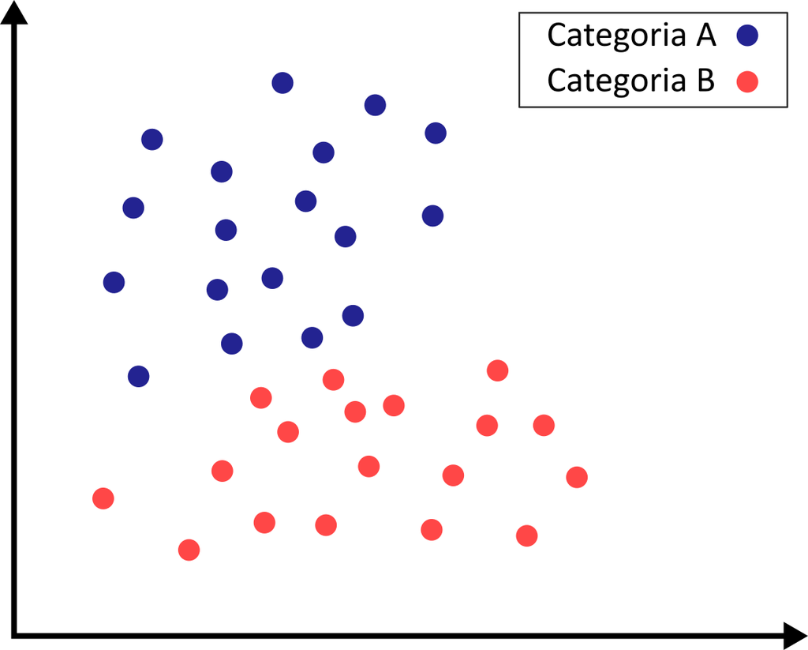

Quando um novo ponto for introduzido no conjunto de dados, o algoritmo KNN irá prever a qual categoria ele irá pertencer.

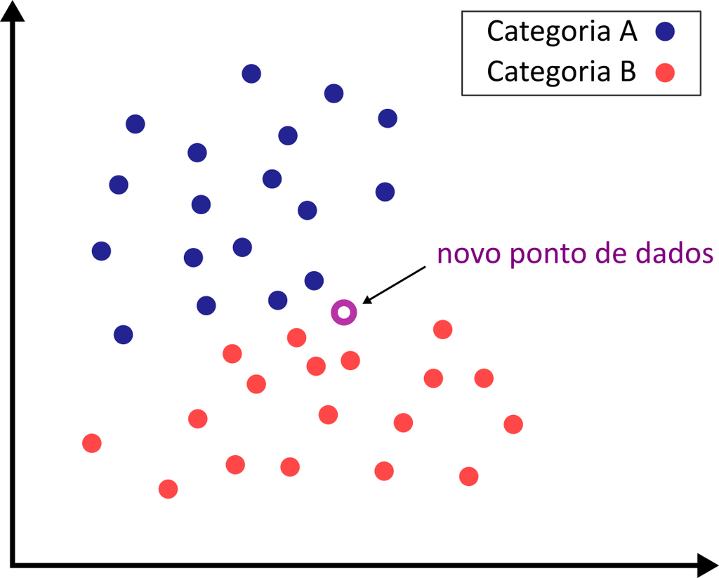

Vamos supor aqui um valor de k = 5 vizinhos mais próximos. Quando o novo ponto é introduzido, o algoritmo irá identificar os 5 vizinhos mais próximos dele, e a categoria que tiver o maior número de vizinhos é a que esse novo ponto irá pertencer.

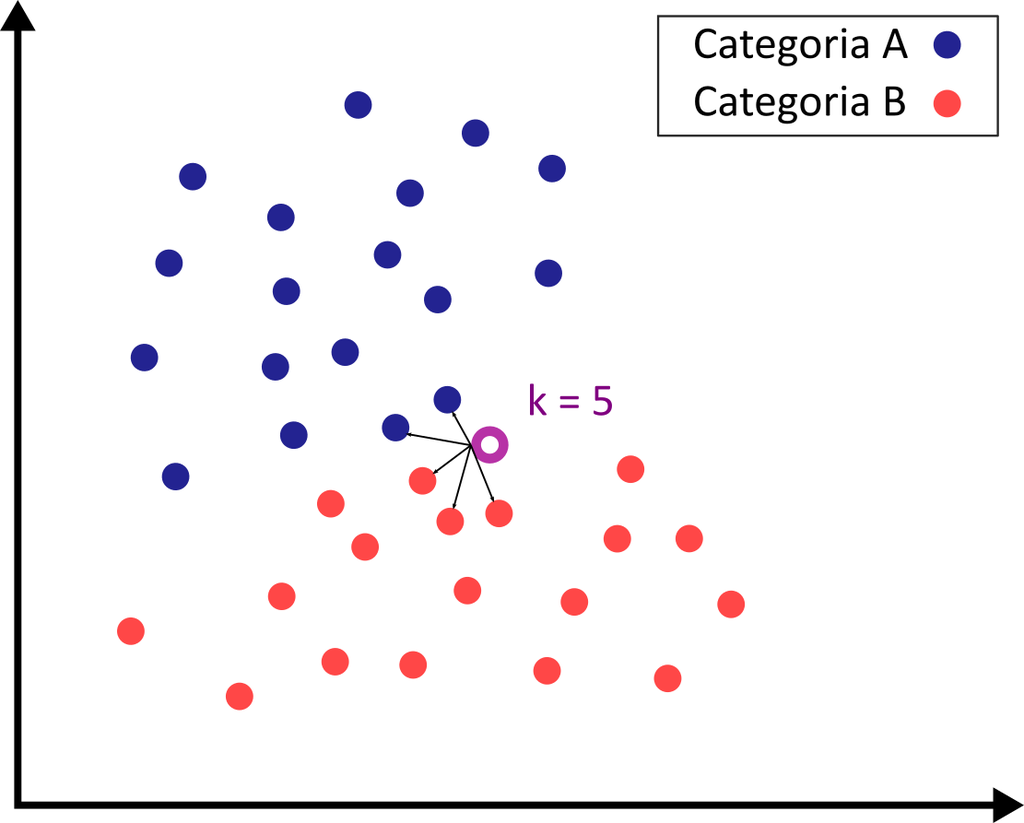

No caso desse exemplo, o novo ponto irá pertencer à categoria B.

Outros detalhes do algoritmo, o leitor interessado pode consultar [aqui](https://www.analyticsvidhya.com/blog/2021/04/simple-understanding-and-implementation-of-knn-algorithm/), [aqui](https://www.javatpoint.com/k-nearest-neighbor-algorithm-for-machine-learning) e [aqui](https://www.ibm.com/topics/knn), além de vários outros sites na internet.

#### **Treinando o modelo**

Vamos inicialmente dividir o conjunto de dados em treino (80%) e teste (20%):

```r
# amostrar aleatoriamente os índices de 80% dos dados
split <- sample.int(n = nrow(dados_norm),
                    size = floor(0.8*nrow(dados_norm)),
                    replace = F)

# tomar os dados de treino a partir dos índices obtidos
treino <- dados_norm[split,]

# obter os dados de teste excluindo os dados de treino
teste <- dados_norm[-split,]
```

Além da classificação dos dados em treino e teste, temos que indicar para cada observação, o valor real da variável target, neste caso, o diagnóstico benigno ou maligno, que está armazenado na primeira coluna do objeto `dados`:

```r
treino_target <- dados[split,1]
teste_target <- dados[-split,1]
```

Para treinar o modelo vamos utilizar o pacote `class`, com a função `knn()`. Como argumentos para a função, devemos fornecer os dados de treino e teste, o fator de classificações verdadeiras do conjunto de treino e o número k de vizinhos. Inicialmente vamos considerar um valor de k = 5:

```r
library(class)

modelo = knn(train = treino,
             test = teste,
             cl = treino_target,
             k = 5)

summary(modelo)
```

```
## benigno maligno
##      74      40
```

O modelo previu então, nas 114 observações do conjunto de teste, 74 como benigno e 40 como maligno.

#### **Avaliando o modelo**

Para fazer a avaliação do modelo, uma ferramenta importante é a **matriz de confusão**, que mostra o número de previsões corretas e incorretas feitas pelo modelo de classificação em comparação com os resultados reais (variável target) nos dados. Na matriz de confusão com duas classes encontramos os seguintes resultados

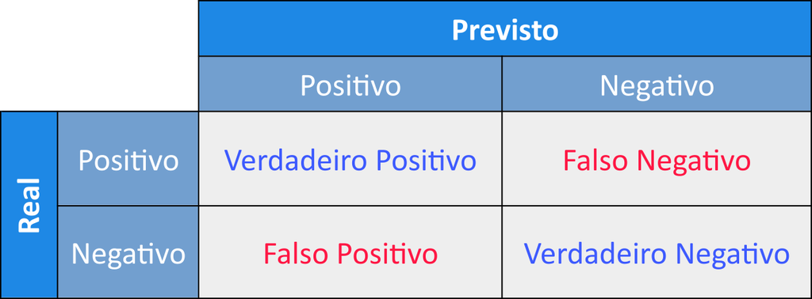

Vamos avaliar com base na acurácia, quão bem o modelo se comportou com o número de vizinhos k = 5. O cálculo da acurácia é dado por

$$Acurácia = \frac{Verdadeiros~ Positivos + Verdadeiros~
Negativos}{Tamanho ~ da ~amostra ~de ~teste}$$

Para construir a matriz de confusão utilizaremos o pacote `caret`

```r
library('caret')

conf_mat <- confusionMatrix(data = teste_target,
                            reference = modelo)


conf_mat
```

```
## Confusion Matrix and Statistics
##
##           Reference
## Prediction benigno maligno
##    benigno      70       1
##    maligno       4      39
##
##                Accuracy : 0.9561
##                  95% CI : (0.9006, 0.9856)
##     No Information Rate : 0.6491
##     P-Value [Acc > NIR] : 2.976e-15
##
##                   Kappa : 0.9053
##
##  Mcnemar's Test P-Value : 0.3711
##
##             Sensitivity : 0.9459
##             Specificity : 0.9750
##          Pos Pred Value : 0.9859
##          Neg Pred Value : 0.9070
##              Prevalence : 0.6491
##          Detection Rate : 0.6140
##    Detection Prevalence : 0.6228
##       Balanced Accuracy : 0.9605
##
##        'Positive' Class : benigno
##
```

Observe que, além da matriz de confusão, há uma série de estatísticas apresentadas, entre elas a acurácia, que foi de 95,61%. Na matriz de confusão temos que o modelo acertou 70 + 39 = 109 dos casos e errou 4 + 1 = 5 casos (109114 = 0.9561).

No objeto `conf_mat` obtido anteriormente, a acurácia está armazenada em `conf_mat$overall[1]`:

```r
conf_mat$overall[1]
```

```
##  Accuracy
## 0.9561404
```

Vamos então executar o K-NN para diferentes valores de k e obter as acurácias :

```r
k_val = seq(from=1, to=30,by=2)
acuracia = NULL

for (i in k_val) {

  mod_temp = knn(train = treino,
             test = teste,
             cl = treino_target,
             k = i)

  confusion_mat <- confusionMatrix(data = teste_target,
                            reference = mod_temp)

  acuracia <- append(acuracia,unname(confusion_mat$overall[1]))
}
```

Vamos fazer um gráfico com as acurácias para cada valor de k:

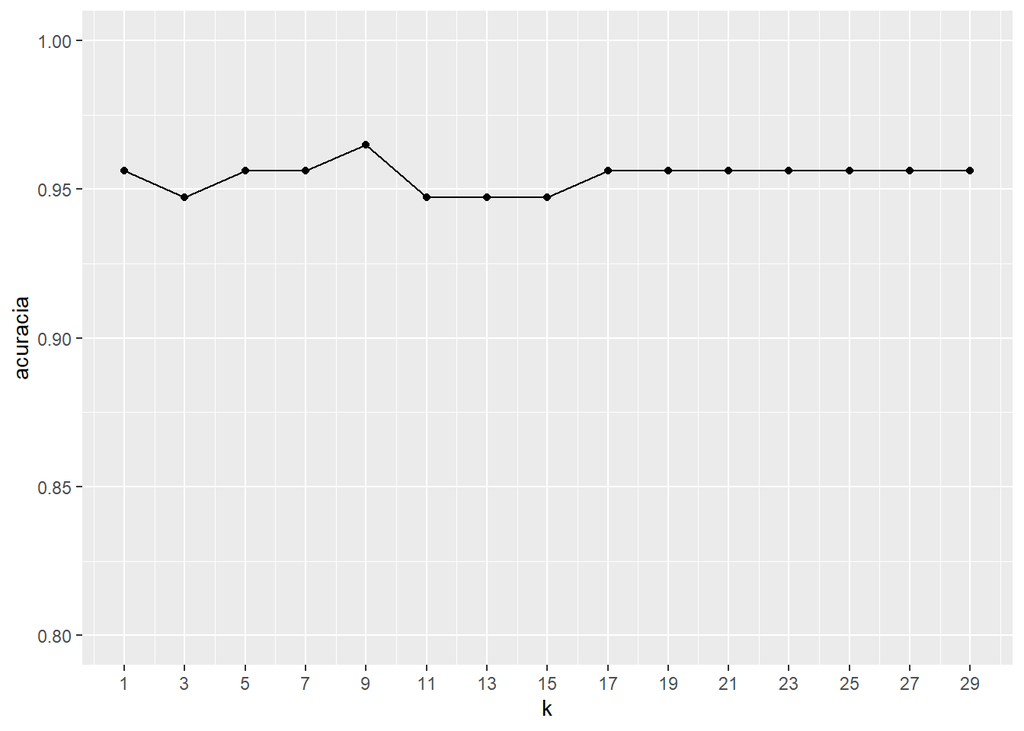

```r
df <- data.frame(k_val,acuracia)

ggplot(data = df,
       aes(x = k_val, y = acuracia)) +
  geom_point()+
  geom_line() +
  scale_x_continuous(name ="k", breaks = seq(from=1, to=30,by=2)) +
  scale_y_continuous(limits = seq(from=0.8, to=1,by=0.2))
```

Embora tenha um funcionamento simples, o KNN é considerado um algoritmo preguiçoso (lazy), porque não aprende uma função discriminativa dos dados de treinamento, mas “memoriza” o conjunto de dados de treinamento. Cada vez que um novo ponto de dados chega e queremos fazer uma previsão, o algoritmo KNN buscará os vizinhos mais próximos em todo o conjunto de treinamento. Assim, a etapa de previsão torna-se mais demorada e computacionalmente cara.